# R for beginners

### Corrplots and heatmaps

if you quickly wanted to convey to the reader the strenght of correlations between several variables, you should use plots.

We have discussed before the scatterplot. But a fancier, and sometimes more useful, way of showing correlation strenghts is a corrplot

Use the function `corrplot()` from the package with the same name. The size and color of the circles indicate the strength and direction of the correlation. check out the many options.

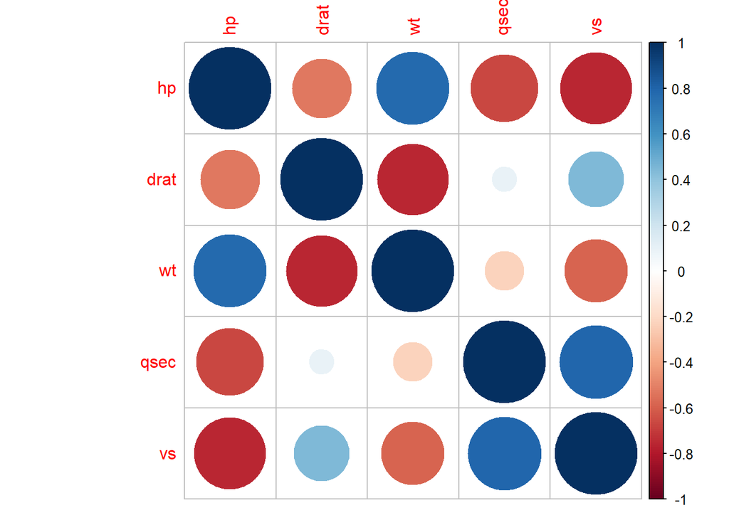

```r
# install.packages('corrplot')
library(corrplot)
mycorrs <- cor(mtcars[, 4:8], use = "complete.obs", method = "spearman")
corrplot(mycorrs)
```

Othertimes so-called **heat maps** are useful to quickly spot clusters of associations amongst many variables.

For a famous example, check out the paper “Matching Categorical Object Representations in Inferior Temporal Cortex of Man and Monkey”, published in *Neuron* by Kriegeskorte and colleagues (2008)

[figure not shown]

Now let’s do our own (slightly less fancy) heat map with the `mtcars` dataset

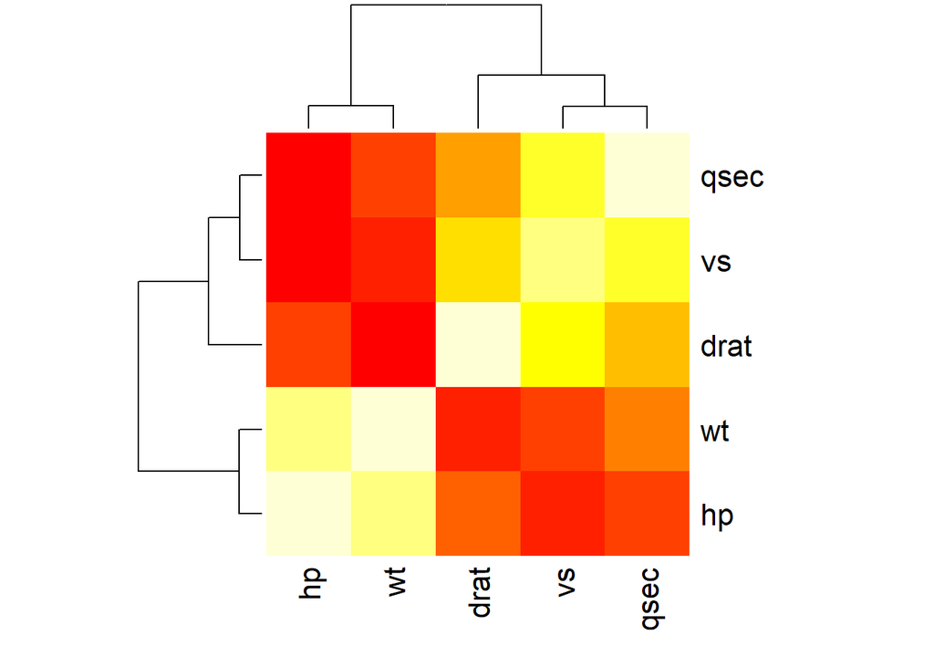

```r
mycorrs <- cor(mtcars[, 4:8], use = "complete.obs", method = "spearman")
heatmap(mycorrs)
```

### Student’s t-test

The t-test allows us to test

- if the average of a variable differs significantly from a specific number (One-sample t-test)
- if two groups of subjects differ from each other (Independent-samples t-test)
- if two measures, which were taken on the same group of subjects, differ from each other (Paired-samples t-test)

It is important to remember, that with a t-test you can only compare a max of 2 groups, or 2 conditions. Use ANOVA or linear mixed models if you have more groups and/or conditions.

By default, the function `t.test()` assumes unequal variances and applies the Welsh degrees of freedom (df) modification. To specify equal variances, use the `var.equal = TRUE` option.

#### One-sample t-test

- For testing if the mean of a sample differs significantly from 0 (or any other number).

For example, we could test if the average horse power of all cars in the dataset mtcars differs from 0 (which it does), and from 150 (which it doesn’t)

```r
t.test(mtcars$hp, mu = 0)
```

```
##
##  One Sample t-test
##
## data:  mtcars$hp
## t = 12.103, df = 31, p-value = 2.794e-13
## alternative hypothesis: true mean is not equal to 0
## 95 percent confidence interval:
##  121.9679 171.4071
## sample estimates:
## mean of x
##  146.6875
```

```r
t.test(mtcars$hp, mu = 150)
```

```
##
##  One Sample t-test
##
## data:  mtcars$hp
## t = -0.2733, df = 31, p-value = 0.7864
## alternative hypothesis: true mean is not equal to 150
## 95 percent confidence interval:
##  121.9679 171.4071
## sample estimates:
## mean of x
##  146.6875
```

#### Independent t-test

- For testing the difference between 2 unrelated samples (i.e. different subjects in two groups or conditions - imagine comparing men with women, or drug 1 with drug 2)

Attention: The specification of the formula depends depending on whether your data is in long or wide format

In long format we specify a numeric and a binary factor (separated by “~”):

```r
# select only chicken that followed diets 1 or 2 (we can only compare 2 groups with t-test):
ChickWeight_temp <- ChickWeight[ChickWeight$Diet == 1 | ChickWeight$Diet == 2, ]

# average across chicken by time and diet
ChickWeight_temp_long <- aggregate(ChickWeight_temp, by = list(ChickWeight_temp$Time, ChickWeight_temp$Diet), FUN = mean, na.rm = TRUE)

# make a bit nicer
ChickWeight_temp_long <- ChickWeight_temp_long[, c(1:3)]
colnames(ChickWeight_temp_long)[1:2] <- c("Time", "Diet")

# now test if weight differs between diet 1 and 2
t.test(ChickWeight_temp_long$weight ~ as.factor(ChickWeight_temp_long$Diet))
```

```
##
##  Welch Two Sample t-test
##
## data:  ChickWeight_temp_long$weight by as.factor(ChickWeight_temp_long$Diet)
## t = -0.74786, df = 20.988, p-value = 0.4628
## alternative hypothesis: true difference in means is not equal to 0
## 95 percent confidence interval:
##  -63.98631  30.13885
## sample estimates:
## mean in group 1 mean in group 2
##        105.6929        122.6167
```

Assume equal variances (this changes the dfs, and slightly the p value):

```r
t.test(ChickWeight_temp_long$weight ~ as.factor(ChickWeight_temp_long$Diet), var.equal = TRUE)
```

```
##
##  Two Sample t-test
##
## data:  ChickWeight_temp_long$weight by as.factor(ChickWeight_temp_long$Diet)
## t = -0.74786, df = 22, p-value = 0.4625
## alternative hypothesis: true difference in means is not equal to 0
## 95 percent confidence interval:
##  -63.85473  30.00727
## sample estimates:
## mean in group 1 mean in group 2
##        105.6929        122.6167
```

Change to 1-tailed t-test (modifies the *p* value)

```r
t.test(ChickWeight_temp_long$weight ~ as.factor(ChickWeight_temp_long$Diet), var.equal = TRUE, alternative = "less")
```

```
##
##  Two Sample t-test
##
## data:  ChickWeight_temp_long$weight by as.factor(ChickWeight_temp_long$Diet)
## t = -0.74786, df = 22, p-value = 0.2312
## alternative hypothesis: true difference in means is less than 0
## 95 percent confidence interval:
##      -Inf 21.93463
## sample estimates:
## mean in group 1 mean in group 2
##        105.6929        122.6167
```

```r
t.test(ChickWeight_temp_long$weight ~ as.factor(ChickWeight_temp_long$Diet), var.equal = TRUE, alternative = "greater")
```

```
##
##  Two Sample t-test
##
## data:  ChickWeight_temp_long$weight by as.factor(ChickWeight_temp_long$Diet)
## t = -0.74786, df = 22, p-value = 0.7688
## alternative hypothesis: true difference in means is greater than 0
## 95 percent confidence interval:
##  -55.78209       Inf
## sample estimates:
## mean in group 1 mean in group 2
##        105.6929        122.6167
```

Now let’s put the same data in wide format, to compare 2 numeric factors (separated by “,”):

```r
library(reshape2)
ChickWeight_temp_wide <- dcast(ChickWeight_temp_long, Time ~ Diet, value.var = "weight")
colnames(ChickWeight_temp_wide)[2:3] <- c("Diet1", "Diet2")
t.test(ChickWeight_temp_wide$Diet1, ChickWeight_temp_wide$Diet2)
```

```
##
##  Welch Two Sample t-test
##
## data:  ChickWeight_temp_wide$Diet1 and ChickWeight_temp_wide$Diet2
## t = -0.74786, df = 20.988, p-value = 0.4628
## alternative hypothesis: true difference in means is not equal to 0
## 95 percent confidence interval:
##  -63.98631  30.13885
## sample estimates:
## mean of x mean of y
##  105.6929  122.6167
```

It is important to point out that you get the same *t* and *p* values and dfs using the data in long or wide format!

#### Dependent (paired-sample) t-test

- For testing difference between two related samples (i.e. same people tested twice)

We could use the same ChickenWeight data, but this time compare identical chicken across 2 time points.

IMPORTANT: add the option PAIRED

In long format we specify a numeric and a binary factor (separated by “~”):

```r
# select only Time 1 and 2:
ChickWeight_temp <- ChickWeight[ChickWeight$Time <= 2, ]
t.test(ChickWeight_temp$weight ~ as.factor(ChickWeight_temp$Time), paired = TRUE)
```

```
##
##  Paired t-test
##
## data:  ChickWeight_temp$weight by as.factor(ChickWeight_temp$Time)
## t = -15.907, df = 49, p-value < 2.2e-16
## alternative hypothesis: true difference in means is not equal to 0
## 95 percent confidence interval:
##  -9.190877 -7.129123
## sample estimates:
## mean of the differences
##                   -8.16
```

In the wide format, we specify 2 numeric factors (separated by “,”)

```r
library(reshape2)
ChickWeight_temp <- ChickWeight[ChickWeight$Time <= 2, ]
ChickWeight_temp_wide <- dcast(ChickWeight_temp, Chick + Diet ~ Time, value.var = "weight")
colnames(ChickWeight_temp_wide)[3:4] <- c("time0", "time2")
t.test(ChickWeight_temp_wide$time0, ChickWeight_temp_wide$time2, paired = TRUE)
```

```
##
##  Paired t-test
##
## data:  ChickWeight_temp_wide$time0 and ChickWeight_temp_wide$time2
## t = -15.907, df = 49, p-value < 2.2e-16
## alternative hypothesis: true difference in means is not equal to 0
## 95 percent confidence interval:
##  -9.190877 -7.129123
## sample estimates:
## mean of the differences
##                   -8.16
```

### Mann-Whitney U & Wilcoxon signed ranks tests

One of the assumptions of the t-test, is that the data are normally distributed. However, even in cases when the data is NOT normally distributed, one can use the t-test as long as the sample size is reasonably large: N at least >10, better >100. Thus, the t-test is quite robust for violations of the normality assumption, as long as the sample is not too small.

An alternative to the t-test exists , which does not require normal distribution of the data:

The non-parametric *Mann-Whitney U* test (also called Mann-Whitney-Wilcoxon, Wilcoxon rank-sum, or Wilcoxon-Mann-Whitney test) can be used as alternative to the *independent t-test*.

Itis calculated in 2 different ways, depending on the sample size (<20 or >20). In any case, it involves some ranking of the values of both groups, and does not assume normal distribution of the data.

The *Wilcoxon signed ranks* test can be used as an alternative to the *dependent t-test*

Implementation of these nonparametric tests is easy, and the formula almost identical to the t-test one.

Here an example of the Mann-Whitney U test:

```r
# select again only chicken that followed diets 1 or 2 (we can only compare 2 groups with t-test or Mann-Whitney):
ChickWeight_temp <- ChickWeight[ChickWeight$Diet == 1 | ChickWeight$Diet == 2, ]
wilcox.test(ChickWeight_temp[, 1], ChickWeight_temp[, 2])
```

```
##
##  Wilcoxon rank sum test with continuity correction
##
## data:  ChickWeight_temp[, 1] and ChickWeight_temp[, 2]
## W = 115600, p-value < 2.2e-16
## alternative hypothesis: true location shift is not equal to 0
```

And here an example of the Wilcoxon signed ranks test:

```r
# select only Time 1 and 2 (applied to all chicken):
ChickWeight_temp <- ChickWeight[ChickWeight$Time <= 2, ]
# put Time in wide format
library(reshape2)
ChickWeight_temp_wide <- dcast(ChickWeight_temp, Chick + Diet ~ Time, value.var = "weight")
colnames(ChickWeight_temp_wide)[3:4] <- c("time0", "time2")
# perform statistics:
wilcox.test(ChickWeight_temp_wide$time0, ChickWeight_temp_wide$time2, paired = TRUE)
```

```
##
##  Wilcoxon signed rank test with continuity correction
##
## data:  ChickWeight_temp_wide$time0 and ChickWeight_temp_wide$time2
## V = 8, p-value = 1.132e-09
## alternative hypothesis: true location shift is not equal to 0
```

### Simple regression

A simple linear regression is similar to a correlation: You want to know the link between two variables. In a regression, however, you go further than in a correlation, as you want to know how much y depends (is predicted by) x.

A regression therefore tries to predict changes in the dependent variable based on 1 or more independent variables (predictors), even for a range of the IV that is yet unknown.

For example, the mtcars dataset includes cars that have between 52 and 335 horse power. By fitting a regression model with miles per gallon (mpg) as DV, and horse power (hp) as IV, we can try to predict what the mpg would be for a car with 400 hp.

The general formula for a linear regression is `lm(DV ~ IV, yourdata)`, where DV is the dependent variable, and IV the independent one. Get the result using `summary()`, or `anova()`.

Let’s test if the horsepower of cars predicts their gas consumption (in mpg):

```r
model1 <- lm(mpg ~ hp, mtcars)
summary(model1)
```

```
##
## Call:
## lm(formula = mpg ~ hp, data = mtcars)
##
## Residuals:
##     Min      1Q  Median      3Q     Max
## -5.7121 -2.1122 -0.8854  1.5819  8.2360
##
## Coefficients:
##             Estimate Std. Error t value Pr(>|t|)
## (Intercept) 30.09886    1.63392  18.421  < 2e-16 ***
## hp          -0.06823    0.01012  -6.742 1.79e-07 ***
## ---
## Signif. codes:  0 '***' 0.001 '**' 0.01 '*' 0.05 '.' 0.1 ' ' 1
##
## Residual standard error: 3.863 on 30 degrees of freedom
## Multiple R-squared:  0.6024, Adjusted R-squared:  0.5892
## F-statistic: 45.46 on 1 and 30 DF,  p-value: 1.788e-07
```

How to read the output:

R-squared informs us about the amount of variance of mpg that is explained by the model (in this case 60%). Since a simple regression only includes 1 IV, R-squared also represents how much variance is explained by hp. If you take the square root of R-squared, you get the Pearson correlation coefficient *r*: `sqrt(0.6024) = 0.77` Thus, there is a strong correlation between mpg and hp.

The Adjusted R-squared indicates how well the model generalizes to the population. This value should be close to R-squared, but is typically a bit smaller.

The significant F-Statistic in the last line informs us that the model predicts well the DV. Since the model only includes 1 IV, the F-Statistic in this case also tells us that hp is a good predictor of mpg.

The most important part of the output is the Coefficients table:

- the estimate in the line (Intercept), gives the intercept of the model’s line, i.e. how many miles per gallon you could drive if your car had 0 horse power: 30! (our model obviously doesn’t understand much of cars, otherwise it would know that a car with 0 hp does not drive at all)
- The line starting with “hp” gives: the estimate of how much mpg changes for 1-point change in hp (it is the slope, or gradient, of the line best representing the data). The *t* value indicates the magnitude of the IV’s effect, and the *p* value its statistical significance. Notice that the estimate for hp is negative, because indeed there is a negative relation between mpg and hp: the stronger the car, the fewer mpg of gas you can drive. The estimate also tells us that for every additional horse power you lose 0.068 mpg. Thus, a car with 400 hp would have 2.8 mpg (the result of 30.09886 - (0.06823 * 400)).

Let’s verify these things by plotting the scatterplot with the fitted regression line. To have the line extend all the way from 0 to 400 hp, we need to include `xlim(0,400)` and the `fullrange=TRUE` option.

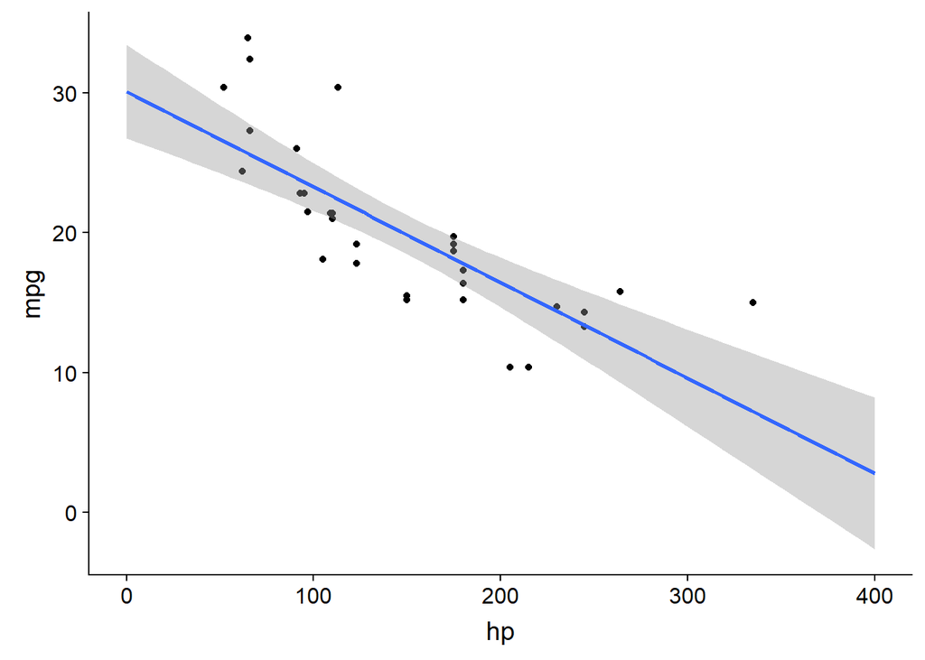

```r
library(ggplot2)
ggplot(mtcars, aes(x = hp, y = mpg)) + geom_point() + xlim(0, 400) + stat_smooth(method = "lm", fullrange = TRUE)
```

In the summary of the regression model, the 3rd line from the bottom provides the degrees of freedom (30).

The statistics can be reported like this: hp significantly predicted mpg, as confirmed by linear regression (*t*(30) = -6.742, *p* < .001, R-squared = .6).

### Multiple regression

Same as simple regression, only that you want to predict changes in the DV based on several IVs.

A more complicated model, that icludes several predictors, could help explain more variance, and thus achieve a greater R-squared.

You can compare the fit (R-squared) of different regression models using the function `anova()`.

For example, do we explain more variance by also including the car’s cylinders?

```r
model1 <- lm(mpg ~ hp, mtcars)
model2 <- lm(mpg ~ hp + cyl, mtcars)
anova(model1, model2)
```

```
## Analysis of Variance Table
##
## Model 1: mpg ~ hp
## Model 2: mpg ~ hp + cyl
##   Res.Df    RSS Df Sum of Sq      F    Pr(>F)
## 1     30 447.67
## 2     29 291.97  1     155.7 15.465 0.0004804 ***
## ---
## Signif. codes:  0 '***' 0.001 '**' 0.01 '*' 0.05 '.' 0.1 ' ' 1
```

Yes we do. The comparison of the 2 models showed that model2 fits better to the data. The R-squared of the 2nd model (the more complex one that includes 2 predictors) is 0.74, and thus significantly bigger than the R-squared of the 1st model (0.60).

```r
c("mod1: ", round(summary(model1)$r.squared, digits = 2))
```

```
## [1] "mod1: " "0.6"
```

```r
c("mod2: ", round(summary(model2)$r.squared, digits = 2))
```

```
## [1] "mod2: " "0.74"
```

By using multiple instead of simple regression, we were able to explain 14% more variance!

Which of the 2 IVs is more important in mod2? To answer that question, we can look at their estimates, SEs, and t-values:

```r
summary(model2)$coefficients
```

```
##               Estimate Std. Error   t value     Pr(>|t|)
## (Intercept) 36.9083305 2.19079864 16.846975 1.620660e-16
## hp          -0.0191217 0.01500073 -1.274718 2.125285e-01
## cyl         -2.2646936 0.57588924 -3.932516 4.803752e-04
```

Only cyl significantly predicts mpg (as indicated by the p value being < .05).Therefore, the number of cylinders of a car has a bigger effect on gas consumption than horse power.

Another way to look at this is by using the standardized estimates. For that, we use the function `lm.beta()` from the package `QuantPsyc`

```r
library(QuantPsyc)
lm.beta(model2)
```

```
##         hp        cyl
## -0.2175294 -0.6710802
```

The standardized beta estimates indicate that gas concumption increases (mpg decreases) by 0.67 standard deviations (SDs), when the number of cylinders increases by 1 SD. The same change in hp only leads to a 0.21 SD change in mpg.

Similarly, the 95% confidence interval (CI) of the unstandardized beta estimate for cyl does not cross 0, compared to the CI for hp. This clearly indicates that among the 2 predictors, the number of cylinders is more reliable (the slope is always negative) and plays a bigger role.

```r
confint(model2)
```

```
##                   2.5 %      97.5 %
## (Intercept) 32.42764417 41.38901679
## hp          -0.04980163  0.01155824
## cyl         -3.44251935 -1.08686785
```

We can also represent the size of each estimate, and the CI around it, using the function `plot_model()` of the package `sjPlot`. I have sorted the highest effect at the top.

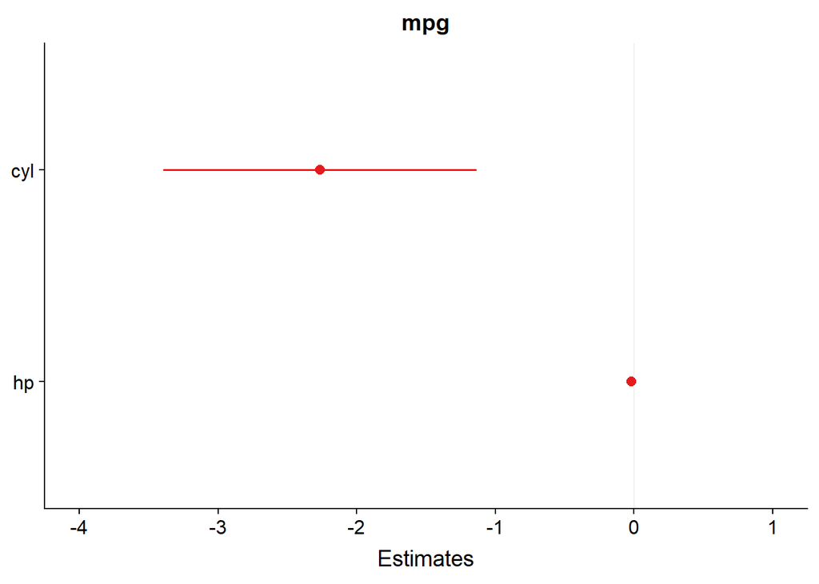

```r
library(sjPlot)
plot_model(model2)
```

One could also add more IVs to the model. However, adding displacement (disp) does not significantly improve model fit

```r
model2 <- lm(mpg ~ hp + cyl, mtcars)
model3 <- lm(mpg ~ hp + cyl + disp, mtcars)
anova(model2, model3)
```

```
## Analysis of Variance Table
##
## Model 1: mpg ~ hp + cyl
## Model 2: mpg ~ hp + cyl + disp
##   Res.Df    RSS Df Sum of Sq      F  Pr(>F)
## 1     29 291.98
## 2     28 261.37  1    30.605 3.2787 0.08093 .
## ---
## Signif. codes:  0 '***' 0.001 '**' 0.01 '*' 0.05 '.' 0.1 ' ' 1
```

Adding weight (wt) does improve the model significantly:

```r
model2 <- lm(mpg ~ hp + cyl, mtcars)
model4 <- lm(mpg ~ hp + cyl + wt, mtcars)
anova(model2, model4)
```

```
## Analysis of Variance Table
##
## Model 1: mpg ~ hp + cyl
## Model 2: mpg ~ hp + cyl + wt
##   Res.Df    RSS Df Sum of Sq      F    Pr(>F)
## 1     29 291.98
## 2     28 176.62  1    115.35 18.287 0.0001995 ***
## ---
## Signif. codes:  0 '***' 0.001 '**' 0.01 '*' 0.05 '.' 0.1 ' ' 1
```

Indeed, the R-squared is now 0.84. But notice how adding weight to the regression, makes hp and cyl to insignificant predictors (their p values >.05). This is the case because the IVs included in the model are not independent of each other. The estimate (slope) of each IV assumes that the other IVs stay constant, and in fact correspond to their average values. Thus, when weight and horse power do not change, the number of cylinders no longer plays a role!!

```r
summary(model4)
```

```
##
## Call:
## lm(formula = mpg ~ hp + cyl + wt, data = mtcars)
##
## Residuals:
##     Min      1Q  Median      3Q     Max
## -3.9290 -1.5598 -0.5311  1.1850  5.8986
##
## Coefficients:
##             Estimate Std. Error t value Pr(>|t|)
## (Intercept) 38.75179    1.78686  21.687  < 2e-16 ***
## hp          -0.01804    0.01188  -1.519 0.140015
## cyl         -0.94162    0.55092  -1.709 0.098480 .
## wt          -3.16697    0.74058  -4.276 0.000199 ***
## ---
## Signif. codes:  0 '***' 0.001 '**' 0.01 '*' 0.05 '.' 0.1 ' ' 1
##
## Residual standard error: 2.512 on 28 degrees of freedom
## Multiple R-squared:  0.8431, Adjusted R-squared:  0.8263
## F-statistic: 50.17 on 3 and 28 DF,  p-value: 2.184e-11
```

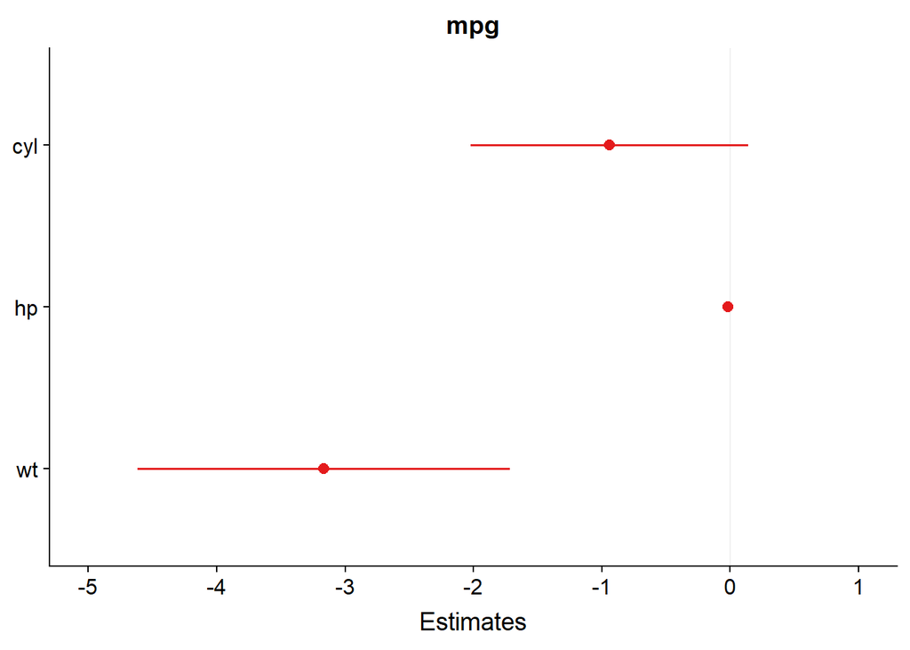

```r
library(sjPlot)
plot_model(model4)
```

### ANOVA (one-way, two-way, within, between, mixed, rep measures)

The Analysis of Variance (ANOVA) is a special case of a linear regression, or linear model, in which the predictor variable(s) are categorical (instead of continuous)

For example, you could have the between-subjects (meaning different for each subject) factor “treatment” with 3 levels: drug A, drug B, and placebo. And/or the within-subjects (meaning every subject does all of them) factor Condition, with 3 levels: Attention to faces, to houses, and control condition.

#### One-way ANOVA

The fact that linear regression and ANOVA are similar, becomes evident by the fact that you can also look at the results of a linear regression using the `anova()` function.

Let’s again regress mpg on hp, using the mtcars data.

```r
summary(lm(mpg ~ hp, mtcars))
```

```
##
## Call:
## lm(formula = mpg ~ hp, data = mtcars)
##
## Residuals:
##     Min      1Q  Median      3Q     Max
## -5.7121 -2.1122 -0.8854  1.5819  8.2360
##
## Coefficients:
##             Estimate Std. Error t value Pr(>|t|)
## (Intercept) 30.09886    1.63392  18.421  < 2e-16 ***
## hp          -0.06823    0.01012  -6.742 1.79e-07 ***
## ---
## Signif. codes:  0 '***' 0.001 '**' 0.01 '*' 0.05 '.' 0.1 ' ' 1
##
## Residual standard error: 3.863 on 30 degrees of freedom
## Multiple R-squared:  0.6024, Adjusted R-squared:  0.5892
## F-statistic: 45.46 on 1 and 30 DF,  p-value: 1.788e-07
```

Notice that in the last line the F-statistics are given. Indeed, you could also look at the results of linear regression using the `anova()` function:

```r
anova(lm(mpg ~ hp, mtcars))
```

```
## Analysis of Variance Table
##
## Response: mpg
##           Df Sum Sq Mean Sq F value    Pr(>F)
## hp         1 678.37  678.37   45.46 1.788e-07 ***
## Residuals 30 447.67   14.92
## ---
## Signif. codes:  0 '***' 0.001 '**' 0.01 '*' 0.05 '.' 0.1 ' ' 1
```

Another way to run an ANOVA and get a results table similar to the one of SPSS, is to use the `aov()` function

The first argument is the dependent variable. It is followed by the tilde symbol (~) and the independent variable(s). finally you give the formula the dataset to be used. you store the analysis in an object, and then look at the results using `summary()`

It is also possible to get the means and number of subjs per cell using `print(model.tables())` - only makes sense with a categorical predictor

Let’s test again if mpg differs by hp

```r
model2 <- aov(mpg ~ hp, mtcars)
summary(model2)
```

```
##             Df Sum Sq Mean Sq F value   Pr(>F)
## hp           1  678.4   678.4   45.46 1.79e-07 ***
## Residuals   30  447.7    14.9
## ---
## Signif. codes:  0 '***' 0.001 '**' 0.01 '*' 0.05 '.' 0.1 ' ' 1
```

And to use a categorical predictor, let’s see if mpg differs by number of cylinders (which it does)

```r
# first convert cyl from numeric to factor
mtcars_temp <- mtcars
mtcars_temp$cyl <- as.factor(mtcars_temp$cyl)
# then run the anova
model3 <- aov(mpg ~ cyl, mtcars_temp)
summary(model3)
```

```
##             Df Sum Sq Mean Sq F value   Pr(>F)
## cyl          2  824.8   412.4    39.7 4.98e-09 ***
## Residuals   29  301.3    10.4
## ---
## Signif. codes:  0 '***' 0.001 '**' 0.01 '*' 0.05 '.' 0.1 ' ' 1
```

A quick way to get the means and number of cars per cylinder-group is to use `model.tables()`:

```r
print(model.tables(model3, "means"), digits = 3)
```

```
## Tables of means
## Grand mean
##
## 20.09062
##
##  cyl
##        4    6    8
##     26.7 19.7 15.1
## rep 11.0  7.0 14.0
```

Do we get the same means with ddply? Yes we do!

```r
ddply(mtcars, c("cyl"), summarise, N_cars = length(cyl), mpg_mean = round(mean(mpg), digits = 1))
```

```
##   cyl N_cars mpg_mean
## 1   4     11     26.7
## 2   6      7     19.7
## 3   8     14     15.1
```

To display boxplots of mpg by cylinder-group:

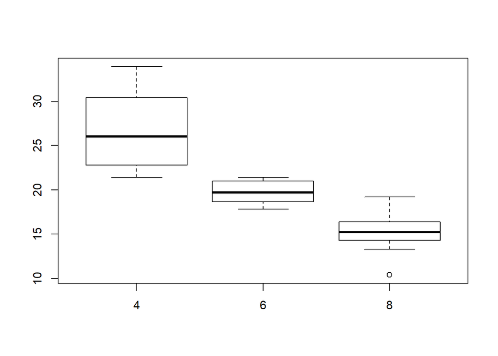

```r
boxplot(mpg ~ cyl, data = mtcars_temp)
```

#### repeated measures ANOVA

See [this introduction](https://www.datacamp.com/courses/repeated-measures-anova) to repeated measures Analysis of Variance (rmANOVA) by DataCamp.

There are different ways of computing an rmANOVA. For example, in his book [Discovering Statistics Using R](https://www.amazon.de/Discovering-Statistics-Using-Andy-Field/dp/1446200469) Andy Field lists 4 ways.

Of these, the `azANOVA()` function from the `az` package is (as of November 2018), not available for the latest R version (3.5.1).

I thus recommend using `aov()`, or a linear mixed model (LMM) with the function `lmer()` from the package `lme4`

## linear regression (LM) - ANOVA

## linear mixed model (LMM)

## Control flow

## Markdown

## More useful functions

##### length(yourVector)